# Bioinformatics 2021 HW_1

huzongyao

October 24, 2024

> - HW2.html
> - Homework1.html

# 1 Homework 2021 Tongji

## 1.1 Problem 1: STAR alignment

We will give you a simple example to test high throughput sequencing alignment for RNA-seq data. Normally for paired-end sequencing data, each sample will have two separate FASTQ files, with line-by-line correspondence to the two reads from the same fragment. Read mapping could take a long time, so we have created just two FASTQ files of one RNA-seq sample with only 30,000 fragments (2 * 30,000 reads) for you to run STAR instead of the full data. The files are located on Huawei Cloud at /mnt/data/data/ HW1/raw_data1. The mapping will generate one single output file.

> 我们将为您提供一个简单的示例，以测试RNA-seq数据的高通量测序比对。通常，对于双端测序数据，每个样本将有两个单独的FASTQ文件，它们的行与来自同一片段的两次读取一一对应。读取比对可能需要很长时间，因此我们仅为您创建了一个包含30,000个片段（2 * 30,000次读取）的RNA-seq样本的两个FASTQ文件，供您运行STAR，而不是完整的数据。文件位于华为云的 /mnt/data/data/HW1/raw_data1。比对将生成一个单一的输出文件。

**Use STAR (Dobin et al, Bioinformatics 2012) to map the reads to the reference genome, available on Huawei Cloud at /mnt/data/data/HW1/index/star_hg38_index. Use the paired-end alignment mode and generate the output in SAM format. Please include full STAR report.How many reads are mappable and how many are uniquely mappable?**

> 使用STAR（Dobin等，Bioinformatics 2012）将读取序列比对到参考基因组，参考基因组可在华为云的 /mnt/data/data/HW1/index/star_hg38_index 上找到。请使用双端比对模式，并生成SAM格式的输出文件。同时请包含完整的STAR报告。请问有多少读取序列是可比对的，有多少是唯一可比对的？

```
Sequencing data:
/mnt/data/data/HW1/raw_data1

module: STAR_2.7.9a
index: /mnt/data/data/HW1/index/star_hg38_index
```

```bash
# 建立输出目录
mkdir ~/Homework_2020/HW1/output/star/
# STAR
STAR --runThreadN 8 \
     --genomeDir ~/HW/HW1/index/star_index \
     --readFilesIn ~/HW/HW1/raw_data1/subA_l.fastq ~/HW/HW1/raw_data1/subA_r.fastq \
     --outFileNamePrefix ~/Homework_2020/HW1/output/star/ \
     --outSAMtype SAM \
     --outSAMunmapped Within \
     --outFilterMultimapNmax 1 \
     --quantMode TranscriptomeSAM GeneCounts
# 查看STAR报告
cat ~/Homework_2020/HW1/output/star/Log.final.out
```

```
                                 Started job on |   Oct 24 18:19:02
                             Started mapping on |   Oct 24 18:21:59
                                    Finished on |   Oct 24 18:22:02
       Mapping speed, Million of reads per hour |   35.99

                          Number of input reads |   29988
                      Average input read length |   96
                                    UNIQUE READS:
                   Uniquely mapped reads number |   19293
                        Uniquely mapped reads % |   64.34%
                          Average mapped length |   95.62
                       Number of splices: Total |   2704
            Number of splices: Annotated (sjdb) |   2673
                       Number of splices: GT/AG |   2677
                       Number of splices: GC/AG |   19
                       Number of splices: AT/AC |   2
               Number of splices: Non-canonical |   6
                      Mismatch rate per base, % |   0.15%
                         Deletion rate per base |   0.01%
                        Deletion average length |   1.50
                        Insertion rate per base |   0.01%
                       Insertion average length |   1.29
                             MULTI-MAPPING READS:
        Number of reads mapped to multiple loci |   0
             % of reads mapped to multiple loci |   0.00%
        Number of reads mapped to too many loci |   8979
             % of reads mapped to too many loci |   29.94%
                                  UNMAPPED READS:
       % of reads unmapped: too many mismatches |   0.00%
                 % of reads unmapped: too short |   5.59%
                     % of reads unmapped: other |   0.14%
                                  CHIMERIC READS:
                       Number of chimeric reads |   0
                            % of chimeric reads |   0.00%
```

> 根据STAR报告：
> - **输入读取序列数量**（Number of input reads）为29988。
> - **多个位点映射的读取数量**（Number of reads mapped to multiple loci）为0。
> - **映射到过多位点的读取数量**（Number of reads mapped to too many loci）为8979。

> 因此：

> **唯一映射的读取数量**（Uniquely mapped reads number）为19293。

## 1.2 Problem 2: RNA-seq quality control

You are asked by a collaborator to analyze four RNA-seq libraries. She suspects that the libraries are generally of high-quality but is concerned that a sample may have been switched with her benchmates during processing. To save time, we have provided four bam file generated by STAR in /mnt/data/data/HW1/raw_data2.

> 您的合作者要求您分析四个 RNA-seq 文库。她怀疑这些文库通常质量较高，但担心在处理过程中某个样本可能与她的同事的样本被混淆。为了节省时间，我们提供了四个由 STAR 生成的 bam 文件，位于 /mnt/data/data/HW1/raw_data2。

**Please use RSeQC (Liguo Wang et al, Bioinformatics 2012) geneBody_coverage.py and tin.py modules to determine whether any of the samples exhibit unusual quality control metrics. To expedite the process, you can use housekeeping genes as reference, which provided in /mnt/data/data/HW1/raw_data2. Overall, identify the best and worst libraries. Your answer should include screen shots and tables as necessary as if you were delivering a report to the collaborator.**

> 请使用 RSeQC (Liguo Wang 等，Bioinformatics 2012) 的 geneBody_coverage.py 和 tin.py 模块，来判断是否有任何样本表现出异常的质量控制指标。为了加快过程，您可以使用提供的管家基因作为参考，这些基因位于 /mnt/data/data/HW1/raw_data2。总体而言，请识别出最好的和最差的文库。您的答案应包括必要的截图和表格，就像您在向合作者提交报告一样。

> 首先安装RSeQC：

> ```bash
> pip install -i https://mirrors.tuna.tsinghua.edu.cn/pypi/web/simple RSeQC
> ```

```
data:
/mnt/data/data/HW1/raw_data2/bamFile
module:RSeQC v4.0.0
```

```bash
# 建立输出目录
mkdir ~/Homework_2020/HW1/output/bam/
# 获取基因覆盖度
geneBody_coverage.py -r ~/HW/HW1/raw_data2/hg38.HouseKeepingGenes.nochr.bed -i ~/HW/HW1/raw_data2/bamFile/res_WAligned.sortedByCoord.out.bam -o ~/Homework_2020/HW1/output/bam/res_WAligned.sortedByCoord.txt
geneBody_coverage.py -r ~/HW/HW1/raw_data2/hg38.HouseKeepingGenes.nochr.bed -i ~/HW/HW1/raw_data2/bamFile/res_XAligned.sortedByCoord.out.bam -o ~/Homework_2020/HW1/output/bam/res_XAligned.sortedByCoord.txt
geneBody_coverage.py -r ~/HW/HW1/raw_data2/hg38.HouseKeepingGenes.nochr.bed -i ~/HW/HW1/raw_data2/bamFile/res_YAligned.sortedByCoord.out.bam -o ~/Homework_2020/HW1/output/bam/res_YAligned.sortedByCoord.txt
geneBody_coverage.py -r ~/HW/HW1/raw_data2/hg38.HouseKeepingGenes.nochr.bed -i ~/HW/HW1/raw_data2/bamFile/res_ZAligned.sortedByCoord.out.bam -o ~/Homework_2020/HW1/output/bam/res_ZAligned.sortedByCoord.txt
# 获取转录本内含子数量
tin.py -r ~/HW/HW1/raw_data2/hg38.HouseKeepingGenes.nochr.bed -i ~/HW/HW1/raw_data2/bamFile/res_WAligned.sortedByCoord.out.bam
tin.py -r ~/HW/HW1/raw_data2/hg38.HouseKeepingGenes.nochr.bed -i ~/HW/HW1/raw_data2/bamFile/res_XAligned.sortedByCoord.out.bam
tin.py -r ~/HW/HW1/raw_data2/hg38.HouseKeepingGenes.nochr.bed -i ~/HW/HW1/raw_data2/bamFile/res_YAligned.sortedByCoord.out.bam
tin.py -r ~/HW/HW1/raw_data2/hg38.HouseKeepingGenes.nochr.bed -i ~/HW/HW1/raw_data2/bamFile/res_ZAligned.sortedByCoord.out.bam
```

> geneBody_coverage 结果：

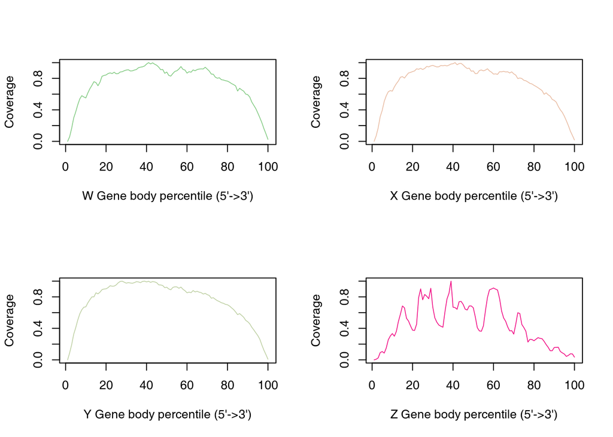

```r
par(mfrow = c(2, 2))
res_WAligned.sortedByCoord.out <- c(0.0,0.059083,0.16568,0.29632,0.37384,0.4639,0.5383,0.5803,0.564,0.5519,0.615,0.6688,0.7107,0.758,0.7471,0.7064,0.7516,0.8266,0.8369,0.8435,0.8612,0.8698,0.8615,0.8776,0.8587,0.861,0.8809,0.8851,0.8973,0.9059,0.9094,0.8945,0.896,0.9057,0.9127,0.9354,0.9424,0.9469,0.9568,0.9817,1.0,0.9835,0.9974,0.9805,0.9671,0.9432,0.9101,0.9129,0.8646,0.8802,0.8371,0.8293,0.8617,0.8886,0.8969,0.9189,0.9503,0.9145,0.9057,0.867,0.8851,0.8783,0.9073,0.897,0.9115,0.9186,0.9205,0.9194,0.9414,0.9175,0.8931,0.8549,0.8519,0.8148,0.8022,0.8075,0.783,0.7790,0.7708,0.7651,0.7517,0.7340,0.7213,0.7050,0.6393,0.6743,0.6539,0.6382,0.6004,0.5932,0.5634,0.5000,0.4577,0.4156,0.3595,0.29976,0.23675,0.16162,0.09622,0.0251) # nolint
res_XAligned.sortedByCoord.out <- c(0.0, 0.06831, 0.16992, 0.3133, 0.393, 0.5077, 0.5788, 0.630, 0.6447, 0.6379, 0.6912, 0.7331, 0.7672, 0.8147, 0.8224, 0.8035, 0.8379, 0.8688, 0.876, 0.8863, 0.8948, 0.9216, 0.916, 0.9277, 0.9125, 0.9267, 0.9513, 0.9461, 0.9588, 0.9651, 0.9545, 0.9458, 0.9477, 0.9638, 0.9604, 0.9652, 0.9585, 0.9684, 0.9824, 0.9863, 1.0, 0.9735, 0.9884, 0.9902, 0.9704, 0.9445, 0.925, 0.9297, 0.8907, 0.8954, 0.8601, 0.8626, 0.8996, 0.9068, 0.8956, 0.9052, 0.922, 0.8949, 0.8787, 0.8544, 0.8574, 0.8509, 0.8851, 0.8833, 0.8897, 0.8818, 0.8838, 0.8684, 0.8828, 0.8572, 0.8417, 0.7971, 0.8051, 0.798, 0.7755, 0.7696, 0.7538, 0.7366, 0.7291, 0.712, 0.6978, 0.6813, 0.6633, 0.6446, 0.5980, 0.6165, 0.5914, 0.5742, 0.5332, 0.5207, 0.49802, 0.44415, 0.4006, 0.368, 0.3197, 0.26187, 0.19932, 0.12877, 0.07459, 0.01735) # nolint
res_YAligned.sortedByCoord.out <- c(0.0, 0.08885, 0.19260, 0.32429, 0.4080, 0.504, 0.5828, 0.636, 0.6684, 0.6735, 0.7241, 0.7639, 0.7998, 0.8, 0.8519, 0.8384, 0.860, 0.8919, 0.8998, 0.9026, 0.9174, 0.9414, 0.9356, 0.9370, 0.9521, 0.9787, 0.9961, 0.9993, 0.9862, 0.9746, 0.9816, 0.9766, 0.9730, 0.9814, 0.9929, 0.9899, 0.981, 0.9958, 1.0, 0.990, 0.9983, 0.9842, 0.9943, 0.9902, 0.9806, 0.9532, 0.9513, 0.9441, 0.9174, 0.9224, 0.9003, 0.8903, 0.92, 0.928, 0.9265, 0.9093, 0.9243, 0.8964, 0.8785, 0.8521, 0.8604, 0.8533, 0.8804, 0.8632, 0.8710, 0.86, 0.8537, 0.8362, 0.8443, 0.8289, 0.8180, 0.7833, 0.7894, 0.7691, 0.7519, 0.7404, 0.7253, 0.7184, 0.7047, 0.6997, 0.6841, 0.6608, 0.6398, 0.6089, 0.5747, 0.5877, 0.5650, 0.5416, 0.5019, 0.48449, 0.458, 0.415, 0.38074, 0.3435, 0.3079, 0.2610, 0.18843, 0.12258, 0.06717, 0.008) # nolint
res_ZAligned.sortedByCoord.out <- c(0.0,0.007541,0.024132,0.09200,0.10558,0.08597,0.15082,0.2549,0.3031,0.334,0.30015,0.36199,0.48717,0.5806,0.6847,0.6606,0.5279,0.49321,0.43137,0.3770,0.3740,0.4539,0.7903,0.9019,0.7631,0.8310,0.808,0.7767,0.9095,0.6681,0.5339,0.4781,0.4419,0.42684,0.41478,0.6093,0.7722,0.8461,1.0,0.669,0.6636,0.6425,0.7390,0.7420,0.7043,0.6440,0.6334,0.6847,0.6847,0.6621,0.5460,0.40874,0.3680,0.363,0.43137,0.6214,0.7918,0.889,0.9004,0.9125,0.8989,0.8868,0.7782,0.6199,0.5324,0.49019,0.4193,0.3680,0.37104,0.3273,0.4539,0.5987,0.5882,0.4494,0.41025,0.363,0.22624,0.2609,0.2579,0.24283,0.26244,0.28205,0.2730,0.2684,0.23529,0.19457,0.15987,0.11613,0.11613,0.1568,0.1583,0.15987,0.10708,0.0889,0.07390,0.043740,0.05731,0.07692,0.07541,0.0347) # nolint
x <- 1:100
icolor <- colorRampPalette(c("#7fc97f", "#beaed4", "#fdc086", "#ffff99", "#386cb0", "#f0027f"))(4)
plot(x, res_WAligned.sortedByCoord.out, type='l', xlab="W Gene body percentile (5'->3')",  ylab="Coverage", lwd=0.8, col=icolor[1])
plot(x, res_XAligned.sortedByCoord.out, type='l', xlab="X Gene body percentile (5'->3')",  ylab="Coverage", lwd=0.8, col=icolor[2])
plot(x, res_YAligned.sortedByCoord.out, type='l', xlab="Y Gene body percentile (5'->3')",  ylab="Coverage", lwd=0.8, col=icolor[3])
plot(x, res_ZAligned.sortedByCoord.out, type='l', xlab="Z Gene body percentile (5'->3')",  ylab="Coverage", lwd=0.8, col=icolor[4])
```

```r
par(mfrow = c(1, 1))
```

> TIN结果：

| **样本** | **平均 TIN 值** | **TIN 中位数** | **TIN 标准差** |
| --- | --- | --- | --- |
| W | 45.74957621202906 | 45.48952930964208 | 21.335829256779135 |
| X | 53.78790168179061 | 55.81711790492213 | 20.627714379280896 |
| Y | 56.20032256195749 | 58.76575560237335 | 19.803630163219655 |
| Z | 24.55179368284309 | 21.92499425956524 | 14.206321489180281 |

> 根据结果可知，样本 Z 的基因体覆盖率较低，TIN 值较低，可能存在质量问题。样本 Y 的基因体覆盖率较高，TIN 值较高，质量较好。

## 1.3 Problem 3: Python programming

**One output of RSeQC is called geneBodyCoverage.r which contains normalized reads mapped to each % of gene / transcript body. Suppose that we want to visualize all 4 samples together to quickly perform quality control. Write a python program to extract the values and name from each file. The same script should then draw the gene body coverage for all the samples (2 rows x 2 cols) in one figure. We provide an example with 3 x 2 samples in one figure. Please identify the worst sample by your result.**

> RSeQC的一个输出文件叫做 `geneBodyCoverage.r`，其中包含了标准化的读取数，这些读取数被映射到基因/转录体的每一个百分比。假设我们想将4个样本一起可视化，以快速进行质量控制。请编写一个Python程序来提取每个文件中的数值和名称。相同的脚本应绘制所有样本的基因体覆盖情况（2行x2列的图形）在一张图中。我们提供了一个3x2样本的示例。请根据你的结果识别出最差的样本。

```python
import os
import numpy as np
import pandas as pd
import matplotlib.pyplot as plt
# 文件路径列表，包含所有需要解析的geneBodyCoverage.r文件
folder = "/home/huzongyao1/Homework_2020/HW1/output/bam"
file_paths = [
    f"{folder}/res_WAligned.sortedByCoord.txt.geneBodyCoverage.r",
    f"{folder}/res_XAligned.sortedByCoord.txt.geneBodyCoverage.r",
    f"{folder}/res_YAligned.sortedByCoord.txt.geneBodyCoverage.r",
    f"{folder}/res_ZAligned.sortedByCoord.txt.geneBodyCoverage.r",
]

# 用于存储样本名和覆盖度数据的字典
data_dict = {}

# 从每个文件中提取样本名称和标准化基因覆盖度数值
for file_path in file_paths:
    with open(file_path, 'r') as file:
        lines = file.readlines()
        sample_name, data_str = lines[0].split(' <- c(')
        data_str = data_str.strip().strip(')')
        values = [float(x) for x in data_str.split(',')]
        data_dict[sample_name] = values

# 转换数据为DataFrame格式
df = pd.DataFrame(data_dict)

# 绘制覆盖度曲线图（2x2布局）
fig, axes = plt.subplots(2, 2, figsize=(12, 10))
fig.suptitle("Gene Body Coverage Across Samples", fontsize=16)

# 将每个样本绘制在子图中
# print(data_dict.items())
for i, (sample_name, values) in enumerate(data_dict.items()):
    ax = axes[i // 2, i % 2]  # 2行2列布局
    ax.plot(np.linspace(0, 100, len(values)), values, label=sample_name)
    ax.set_title(f"{sample_name}")
    ax.set_xlabel("Gene Body percentile (5'->3')")
    ax.set_ylabel("Normalized Read Count")
    ax.legend()

# 检查覆盖度最低的样本
min_coverage_sample = df.mean().idxmin()
print(f"Sample with the lowest average gene body coverage: {min_coverage_sample}")

plt.tight_layout(rect=[0, 0, 1, 0.95])  # 调整布局以适应标题
# 存入文件
plt.savefig("gene_body_coverage.png")
```

> Sample with the lowest average gene body coverage: res_ZAligned.sortedByCoord.out

> 最差的样本显然是 Z

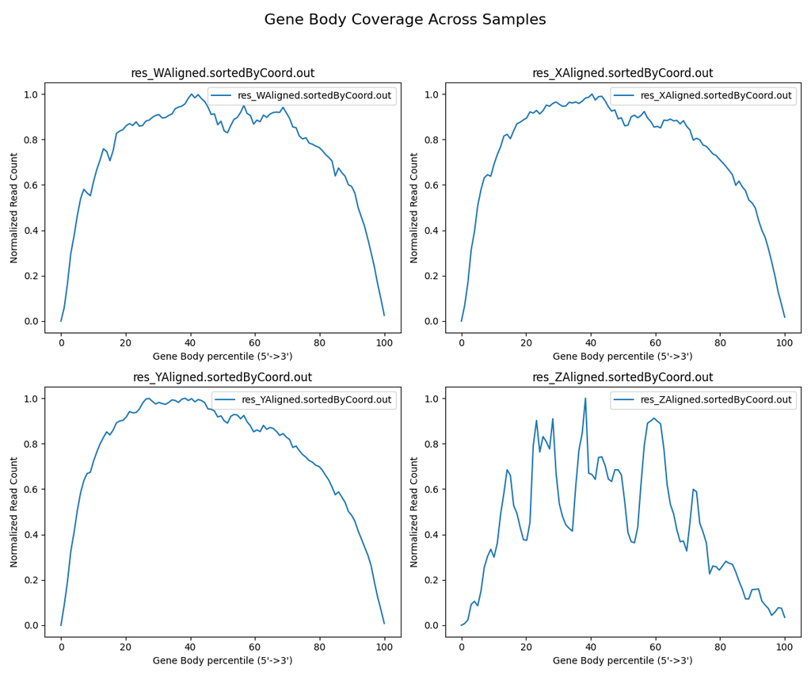

gene_body_coverage